# Quiz3

mail@darrenbishop.com

16 March 2016

```r
library(knitr)
library(ggplot2)
library(ggdendro)
library(gridExtra)
library(rpart.plot)
library(Hmisc)

opts_chunk$set(message=FALSE, warning = FALSE, fig.path="figures/", fig.width=10, fig.align = "center")
```

## Question 1

> 1. Subset the data to a training set and testing set based on the Case variable in the data set.
> 2. Set the seed to 125 and fit a CART model with the rpart method using all predictor variables and default caret settings.
> 3. In the final model what would be the final model prediction for cases with the following variable values:
> 1. TotalIntench2 = 23,000; FiberWidthCh1 = 10; PerimStatusCh1=2
> 2. TotalIntench2 = 50,000; FiberWidthCh1 = 10;VarIntenCh4 = 100
> 3. TotalIntench2 = 57,000; FiberWidthCh1 = 8;VarIntenCh4 = 100
> 4. FiberWidthCh1 = 8;VarIntenCh4 = 100; PerimStatusCh1=2

```r
library(caret)
library(AppliedPredictiveModeling)
data(segmentationOriginal)

trainIndex = createDataPartition(segmentationOriginal$Case, p = 0.7, list = FALSE)
training = segmentationOriginal[trainIndex,]
testing = segmentationOriginal[-trainIndex,]

set.seed(125)
modFit = train(Class ~ ., method = "rpart", data = training)
# tdata = rpart(Class ~ ., method = "class", data = training)
# prp(tdata)
finalModel = modFit$finalModel
print(finalModel)
```

```
## n= 1414
##
## node), split, n, loss, yval, (yprob)
##       * denotes terminal node
##
## 1) root 1414 506 PS (0.64214993 0.35785007)
##   2) TotalIntenCh2< 47244 674  55 PS (0.91839763 0.08160237) *
##   3) TotalIntenCh2>=47244 740 289 WS (0.39054054 0.60945946)
##     6) FiberWidthCh1< 11.19756 310 126 PS (0.59354839 0.40645161) *
##     7) FiberWidthCh1>=11.19756 430 105 WS (0.24418605 0.75581395) *
```

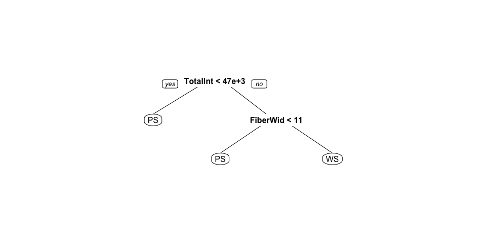

```r
prp(finalModel)
```

```r
# ddata = dendro_data(finalModel)
# ggplot() +
#     geom_segment(data = ddata$segments, aes(x = x, y = y, xend = xend, yend = yend)) +
#     geom_text(data = ddata$labels, aes(x = x, y = y, label = label), size = 5, vjust = -0.4) +
#     geom_text(data = ddata$leaf_labels, aes(x = x, y = y, label = label), size = 5, vjust = 1) +
#     theme_dendro()
```

## Question 2

> If K is small in a K-fold cross validation is the bias in the estimate of out-of-sample (test set) accuracy smaller or bigger? If K is small is the variance in the estimate of out-of-sample (test set) accuracy smaller or bigger. Is K large or small in leave one out cross validation?

*Answer:*

> The bias is larger and the variance is smaller. Under leave one out cross validation K is equal to the sample size.

## Question 3

```r
library(caret)
library(pgmm)
data(olive)
olive = olive[,-1]
```

> These data contain information on 572 different Italian olive oils from multiple regions in Italy. Fit a classification tree where Area is the outcome variable. Then predict the value of area for the following data frame using the tree command with all defaults What is the resulting prediction? Is the resulting prediction strange? Why or why not?

```r
modFit = train(Area ~ ., data = olive, method = "rf", prox = TRUE)
modFit
```

```
## Random Forest
##
## 572 samples
##   8 predictor
##
## No pre-processing
## Resampling: Bootstrapped (25 reps)
##
## Summary of sample sizes: 572, 572, 572, 572, 572, 572, ...
##
## Resampling results across tuning parameters:
##
##   mtry  RMSE       Rsquared   RMSE SD     Rsquared SD
##   2     0.4777018  0.9608779  0.05145482  0.009427885
##   5     0.3996253  0.9713231  0.03727615  0.006048262
##   8     0.4182004  0.9681267  0.05729694  0.009580648
##
## RMSE was used to select the optimal model using  the smallest value.
## The final value used for the model was mtry = 5.
```

```r
finalModel = modFit$finalModel

predict(finalModel, newdata = as.data.frame(t(colMeans(olive))))
```

```
##        1
## 2.643567
```

## Question 4

> Load the South Africa Heart Disease Data and create training and test sets with the following code:

```r
library(ElemStatLearn)
data(SAheart)
set.seed(8484)
train = sample(1:dim(SAheart)[1],size=dim(SAheart)[1]/2,replace=F)
trainSA = SAheart[train,]
testSA = SAheart[-train,]
```

> Then set the seed to 13234 and fit a logistic regression model (method=“glm”, be sure to specify family=“binomial”) with Coronary Heart Disease (chd) as the outcome and age at onset, current alcohol consumption, obesity levels, cumulative tabacco, type-A behavior, and low density lipoprotein cholesterol as predictors. Calculate the misclassification rate for your model using this function and a prediction on the “response” scale:

```r
missClass = function(values,prediction) {
    sum(((prediction > 0.5) * 1) != values) / length(values)
}
```

> What is the misclassification rate on the training set? What is the misclassification rate on the test set?

```r
set.seed(13234)
modFit = train(chd ~ age + alcohol + obesity + tobacco + typea + ldl, data = trainSA, method = "glm", family = "binomial")
modFit
```

```
## Generalized Linear Model
##
## 231 samples
##   9 predictor
##
## No pre-processing
## Resampling: Bootstrapped (25 reps)
##
## Summary of sample sizes: 231, 231, 231, 231, 231, 231, ...
##
## Resampling results
##
##   RMSE       Rsquared   RMSE SD    Rsquared SD
##   0.4366982  0.2000453  0.0239573  0.06521095
##
##
```

```r
finalModel = modFit$finalModel

missClass(trainSA$chd, predict(finalModel, newdata = trainSA, type = "response"))
```

```
## [1] 0.2727273
```

```r
missClass(trainSA$chd, predict(finalModel, newdata = testSA, type = "response"))
```

```
## [1] 0.4761905
```

## Question 5

> Load the vowel.train and vowel.test data sets:

```r
library(dplyr)
library(ElemStatLearn)
data(vowel.train)
data(vowel.test)
```

> Set the variable y to be a factor variable in both the training and test set. Then set the seed to 33833. Fit a random forest predictor relating the factor variable y to the remaining variables. Read about variable importance in random forests here: http://www.stat.berkeley.edu/~breiman/RandomForests/cc_home.htm#ooberr The caret package uses by default the Gini importance.

> Calculate the variable importance using the varImp function in the caret package. What is the order of variable importance?

```r
vowel.train$y = as.factor(vowel.train$y)
vowel.test$y = as.factor(vowel.test$y)

set.seed(33833)
modFit = train(y ~ ., data = vowel.train, method = "rf")
varImp(modFit)
```

```
## rf variable importance
##
##      Overall
## x.2  100.000
## x.1   98.834
## x.5   38.651
## x.6   25.628
## x.8   19.065
## x.4    8.397
## x.9    5.417
## x.3    4.728
## x.7    1.252
## x.10   0.000
```

```r
set.seed(33833)
finalModel = randomForest(y ~ ., data = vowel.train, proximity = TRUE)
t(varImp(finalModel) %>% add_rownames() %>% arrange(desc(Overall)))
```

```
##         [,1]       [,2]       [,3]       [,4]       [,5]       [,6]
## rowname "x.2"      "x.1"      "x.5"      "x.6"      "x.8"      "x.4"
## Overall "91.24009" "89.12864" "50.25539" "43.33148" "42.92470" "34.24433"
##         [,7]       [,8]       [,9]       [,10]
## rowname "x.9"      "x.3"      "x.7"      "x.10"
## Overall "33.37031" "33.08111" "31.88132" "29.59956"
```

*Answer:*

> The order of the variables is:

> x.2, x.1, x.5, x.6, x.8, x.4, x.9, x.3, x.7, x.10